[figure not shown]

# GET00203 - Estatística Computacional 1

Aula 11 - Intervalos de confiança para a variância e conceitos de Testes de Hipóteses

[Rafael Erbisti](https://sites.google.com/site/rerbisti)

### Intervalo de Confiança para a variância

O intervalo de confiança para a variância de uma população normal é baseado na distribuição qui-quadrado ($\chi^2$). Quando a população é normal, a estatística

$$\frac{(n-1)s^2}{\sigma^2} \sim \chi^2_{n-1}$$

segue uma distribuição $\chi^2$ com $n-1$ graus de liberdade, onde:

- $n$ é o tamanho da amostra,
- $s^2$ é a variância amostral,
- $\sigma^2$ é a variância da população.

### Fórmula do intervalo de confiança

O intervalo de confiança para a variância populacional $\sigma^2$ é dado por:

$$\left( \frac{(n-1)s^2}{\chi^2_{1-\alpha/2}},
\frac{(n-1)s^2}{\chi^2_{\alpha/2}} \right)$$

Onde:

- $\chi^2_{1-\alpha/2}$ e $\chi^2_{\alpha/2}$ são os valores críticos da distribuição $\chi^2$ para $n-1$ graus de liberdade,
- $\alpha$ é o nível de significância (com $1-\alpha$ sendo o nível de confiança).

```r
# Parâmetros da população e amostra
sigma2_true = 4   # Variância verdadeira da população
mu = 10           # Média da população
n = 30            # Tamanho da amostra
alpha = 0.05      # Nível de significância

# Gerando uma amostra de uma população normal
amostra = rnorm(n, mean = mu, sd = sqrt(sigma2_true))

# Estatísticas da amostra
s2 = var(amostra) # Variância amostral
df = n - 1        # Graus de liberdade

# Valores críticos da distribuição qui-quadrado
chi2_lower = qchisq(alpha / 2, df)
chi2_upper = qchisq(1 - alpha / 2, df)

# Intervalo de confiança para a variância
ci_lower = (df * s2) / chi2_upper
ci_upper = (df * s2) / chi2_lower

# Exibindo os resultados
cat("Intervalo de confiança para a variância:", ci_lower, "-", ci_upper, "\n")
```

```
Intervalo de confiança para a variância: 2.105452 - 5.998982
```

```r
# Definir parâmetros populacionais
variancia_verdadeira = 4  # Variância verdadeira da população
media_populacao = 10      # Média da população
tamanho_amostra = 30      # Tamanho da amostra
alfa = 0.05               # Nível de significância

# Número de amostras simuladas
n_simulacoes = 1000

# Função para calcular intervalo de confiança
calcular_ic = function(amostra){
  variancia_amostral = var(amostra)
  graus_liberdade = length(amostra) - 1
  chi2_inferior = qchisq(alfa / 2, graus_liberdade)
  chi2_superior = qchisq(1 - alfa / 2, graus_liberdade)

  # Intervalo de confiança
  ic_inferior = (graus_liberdade * variancia_amostral) / chi2_superior
  ic_superior = (graus_liberdade * variancia_amostral) / chi2_inferior
  c(inferior = ic_inferior, superior = ic_superior)
}

# Simular amostras e calcular intervalos
resultados = replicate(n_simulacoes, {
  amostra = rnorm(tamanho_amostra, mean = media_populacao, sd = sqrt(variancia_verdadeira))
  ic = calcular_ic(amostra)
  c(inferior = ic["inferior"], superior = ic["superior"], cobre = variancia_verdadeira >= ic["inferior"] & variancia_verdadeira <= ic["superior"])})

# Converter resultados em um data frame
resultados_df = as.data.frame(t(resultados))
colnames(resultados_df) = c("Inferior", "Superior", "Cobre")
head(resultados_df, 10)
```

```
   Inferior  Superior Cobre
1  3.274427  9.329696     1
2  2.885777  8.222329     1
3  3.242410  9.238471     1
4  2.663612  7.589324     1
5  2.716350  7.739589     1
6  2.065315  5.884620     1
7  2.717152  7.741873     1
8  4.456059 12.696472     0
9  3.406903  9.707153     1
10 2.282967  6.504769     1
```

```r
# Proporção de intervalos que cobrem a variância verdadeira
taxa_cobertura = mean(resultados_df$Cobre)
cat("Proporção de intervalos que cobrem a variância verdadeira:", taxa_cobertura, "\n")
```

```
Proporção de intervalos que cobrem a variância verdadeira: 0.949
```

```r
# Visualização dos intervalos
resultados_df = resultados_df |>
  mutate(Simulacao = row_number())
head(resultados_df, 10)
```

```
   Inferior  Superior Cobre Simulacao
1  3.274427  9.329696     1         1
2  2.885777  8.222329     1         2
3  3.242410  9.238471     1         3
4  2.663612  7.589324     1         4
5  2.716350  7.739589     1         5
6  2.065315  5.884620     1         6
7  2.717152  7.741873     1         7
8  4.456059 12.696472     0         8
9  3.406903  9.707153     1         9
10 2.282967  6.504769     1        10
```

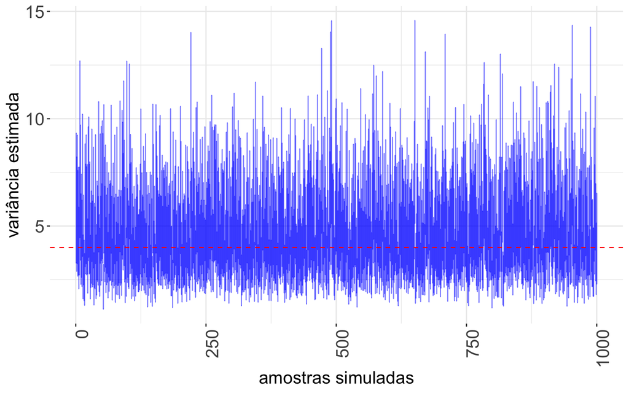

```r
ggplot(resultados_df, aes(x = Simulacao)) +
  geom_errorbar(aes(ymin = Inferior, ymax = Superior), color = "blue", alpha = 0.5) +
  geom_hline(yintercept = variancia_verdadeira, color = "red", linetype = "dashed") +
  labs(y = "variância estimada",
       x = "amostras simuladas") +
  theme_bw() +
  theme(axis.text.x = element_text(size = 16, angle = 90, hjust = 1),
        axis.title.x = element_text(size = 16),
        axis.text.y = element_text(size = 16),
        axis.title.y = element_text(size = 16),
        panel.border = element_blank())
```

### Testes de Hipóteses

Outro interesse central de inferência é testar uma hipótese ou afirmativa sobre um parâmetro populacional. Para isso, usamos os chamados **testes de hipóteses**.

Como em qualquer problema de Inferência, num teste de hipóteses, procura-se tomar decisões a respeito da população com base em informações obtidas a partir de amostras.

*Um teste de hipóteses é um procedimento de Inferência Estatística que gera uma regra de decisão para escolher uma dentre duas hipóteses formuladas sobre um parâmetro desconhecido.*

#### Alguns conceitos sobre Testes de Hipóteses

Vamos ilustrar alguns conceitos básicos através de um exemplo:

Suponha que um crime ocorreu e o detetive suspeita do mordomo. O detetive deve decidir se o mordomo é culpado ou inocente, prendendo-o no primeiro caso.

A hipótese que queremos testar (e que gostaríamos de descartar) é:

$$H_0 : \text{O mordomo é inocente.}$$

Existem quatro possibilidades que podem ocorrer após a decisão do detetive:

$$\begin{array}{|c|c|c|}
\hline
\textbf{Situação Real} & \textbf{Prender} & \textbf{Liberar} \\
\hline
\text{Mordomo Inocente} & \text{Erro Tipo I (falso positivo)} &
\text{Decisão Correta} \\
\hline
\text{Mordomo Culpado} & \text{Decisão Correta} & \text{Erro
Tipo II (falso negativo)} \\
\hline
\end{array}$$

Note que existem duas maneiras diferentes do detetive errar:

- Um **Erro Tipo I** ocorre quando o detetive prende o mordomo, mas ele é inocente.
- Um **Erro Tipo II** ocorre quando o detetive libera o mordomo, mas ele é culpado.

##### Conceitos básicos

- **Hipótese Nula ($H_0$)**: hipótese básica sobre o parâmetro $\theta$ que queremos testar, e que, em geral, buscamos rejeitar através do teste.
  - Se $\theta = \theta_0$ (parâmetro igual a um único valor), dizemos que a hipótese é **simples**.
  - Caso contrário, ela é chamada de **composta**.
- **Hipótese Alternativa ($H_1$)**: hipótese que devemos considerar no caso da rejeição da hipótese nula.
  - No caso de $H_0$ simples, $H_1$ pode ser:
    - **Bilateral**: $H_1 : \theta \neq \theta_0$,
    - **Unilateral à direita**: $H_1 : \theta > \theta_0$,
    - **Unilateral à esquerda**: $H_1 : \theta < \theta_0$.
- **Estatística de Teste**: estimador ou estatística amostral usada para construir o teste.
- **Erro do Tipo I**: rejeitar $H_0$ quando ela é verdadeira.
- **Erro do Tipo II**: não rejeitar $H_0$ quando ela é falsa.
- **Nível de Significância**: probabilidade fixa para o erro do tipo I.
  $$\alpha = P(\text{Erro Tipo I})$$
- **Região Crítica (RC)**: conjunto de valores que leva à rejeição de $H_0$.
  - Se o valor observado para a estatística amostral estiver nesta região, rejeitamos $H_0$.
  - Caso contrário, não rejeitamos $H_0$.

#### Procedimento Geral para Construir um Teste de Hipóteses

Sejam $X$ uma variável aleatória que representa a população e $\theta$ o parâmetro de interesse. Para construir um teste de hipóteses (TH) sobre $\theta$, devemos seguir os seguintes passos:

1. **Definir as hipóteses**:
   - $H_0$: hipótese nula, que em geral buscamos rejeitar.
   - $H_1$: hipótese alternativa, que consideraremos se $H_0$ for rejeitada.
2. **Obter uma estatística de teste** $\hat{\theta}$ e sua distribuição.
3. **Determinar a região crítica (RC)** a partir do nível de significância $\alpha$:
   $$\alpha = P(\text{Erro Tipo I}) = P(\text{Rejeitar } H_0 \mid H_0 \text{
   verdadeira}) =
   P(\hat{\theta} \in RC \mid H_0 \text{ verdadeira})$$
4. **Decidir com base na regra de decisão**:
   - Se o valor observado da estatística de teste, $\hat{\theta} = t$, estiver na região crítica:
     $$t \in RC \implies \text{Rejeitar } H_0 \, (\text{aceitamos } H_1).$$
   - Caso contrário:
     $$t \notin RC \implies \text{Não rejeitar } H_0.$$

#### Exemplo

Para ilustrar os erros do tipo I e II, vamos simular um teste de hipóteses simples em que testamos a média de uma população. A hipótese nula verificará se a média é igual a um valor específico, enquanto a hipótese alternativa verificará se a média é diferente desse valor.

Vamos testar se a média de uma população é igual a 50 ($H_0: \mu = 50$) contra a hipótese alternativa $H_1: \mu \neq 50$. Vamos gerar uma amostra de uma distribuição normal e, com base em um teste $t$, vamos calcular o $p$-valor e determinar se rejeitamos ou não $H_0$ com um nível de significância de 5% ($\alpha = 0.05$).

Se a média verdadeira for 50 (hipótese nula verdadeira), isso nos ajuda a ilustrar um erro Tipo I. Se a média verdadeira for diferente de 50 (hipótese alternativa verdadeira), ilustramos o erro Tipo II.

##### Erro Tipo I

O **erro Tipo I** ocorre quando rejeitamos a hipótese nula ($H_0$) quando ela é verdadeira. Isto significa que fazemos uma conclusão incorreta, rejeitando a hipótese que é, de fato, verdadeira. A probabilidade de cometer um erro Tipo I é o *nível de significância* do teste ($\alpha$).

##### Erro Tipo II

O **erro Tipo II** ocorre quando não rejeitamos a hipótese nula ($H_0$) quando a hipótese alternativa ($H_1$) é verdadeira. Nesse caso, estamos falhando em identificar uma diferença quando ela realmente existe. A probabilidade de cometer um erro Tipo II é denotada por $\beta$.